# Practical Machine Learning

Course Project

Paul Vonck

## Background

Using devices such as Jawbone Up, Nike FuelBand, and Fitbit it is now possible to collect a large amount of data about personal activity relatively inexpensively. These type of devices are part of the quantified self movement – a group of enthusiasts who take measurements about themselves regularly to improve their health, to find patterns in their behavior, or because they are tech geeks. One thing that people regularly do is quantify how much of a particular activity they do, but they rarely quantify how well they do it. In this project, our goal is to use data from accelerometers on the belt, forearm, arm, and dumbell of 6 participants who were asked to perform barbell lifts correctly and incorrectly in 5 different ways. The test set data contains the accelerometer data along with the grade of the movement known as the classe. We will build machine learning models to predict the outcome classe based on test accelerometer data.

## Load Libraries

```r
library(caret)
library(rattle)
```

## Data download

```r
training <- read.csv(url("https://d396qusza40orc.cloudfront.net/predmachlearn/pml-training.csv"),header=TRUE)
dim(training)
```

```
## [1] 19622   160
```

```r
testing <- read.csv(url("https://d396qusza40orc.cloudfront.net/predmachlearn/pml-testing.csv"),header=TRUE)
dim(testing)
```

```
## [1]  20 160
```

## Clean Data

- Remove meta data columns
- Remove predictors with NAs
- Remove predictors with near zero variance

```r
trainingCleaned<- training[, colSums(is.na(training)) == 0]
testingCleaned <- testing[, colSums(is.na(training)) == 0]
trainingCleaned <- trainingCleaned[, -c(1:7)]
testingCleaned <- testingCleaned[, -c(1:7)]
NZV <- nearZeroVar(trainingCleaned)
trainingCleaned <- trainingCleaned[, -NZV]
testingCleaned  <- testingCleaned[, -NZV]
dim(testingCleaned)
```

```
## [1] 20 53
```

```r
dim(trainingCleaned)
```

```
## [1] 19622    53
```

## Show cleaned data structure

- Predictors are numeric
- Outcome (classe) character factor

```r
str(trainingCleaned)
```

```
## 'data.frame':    19622 obs. of  53 variables:
##  $ roll_belt           : num  1.41 1.41 1.42 1.48 1.48 1.45 1.42 1.42 1.43 1.45 ...
##  $ pitch_belt          : num  8.07 8.07 8.07 8.05 8.07 8.06 8.09 8.13 8.16 8.17 ...
##  $ yaw_belt            : num  -94.4 -94.4 -94.4 -94.4 -94.4 -94.4 -94.4 -94.4 -94.4 -94.4 ...
##  $ total_accel_belt    : int  3 3 3 3 3 3 3 3 3 3 ...
##  $ gyros_belt_x        : num  0 0.02 0 0.02 0.02 0.02 0.02 0.02 0.02 0.03 ...
##  $ gyros_belt_y        : num  0 0 0 0 0.02 0 0 0 0 0 ...
##  $ gyros_belt_z        : num  -0.02 -0.02 -0.02 -0.03 -0.02 -0.02 -0.02 -0.02 -0.02 0 ...
##  $ accel_belt_x        : int  -21 -22 -20 -22 -21 -21 -22 -22 -20 -21 ...
##  $ accel_belt_y        : int  4 4 5 3 2 4 3 4 2 4 ...
##  $ accel_belt_z        : int  22 22 23 21 24 21 21 21 24 22 ...
##  $ magnet_belt_x       : int  -3 -7 -2 -6 -6 0 -4 -2 1 -3 ...
##  $ magnet_belt_y       : int  599 608 600 604 600 603 599 603 602 609 ...
##  $ magnet_belt_z       : int  -313 -311 -305 -310 -302 -312 -311 -313 -312 -308 ...
##  $ roll_arm            : num  -128 -128 -128 -128 -128 -128 -128 -128 -128 -128 ...
```

[output cut: 39 more lines]

## Model Fitting

In order to limit the effects of overfitting, and improve the efficicency of the models, we will use 5 fold cross-validation. 10 fold had higher run times with no increased accuracy. We will build models with random forest and generalized boosted models.

```r
library(caret)

set.seed(257)

inTrain1 <- createDataPartition(trainingCleaned$classe, p=0.50, list=FALSE)
finalTrain <- trainingCleaned[inTrain1,]
finalTest <- trainingCleaned[-inTrain1,]

trControl <- trainControl(method="cv", number=5)
model_RF <- train(classe~., data=trainingCleaned, method="rf", trControl=trControl, verbose=FALSE)
model_GBM <- train(classe~., data=trainingCleaned, method="gbm", trControl=trControl, verbose=FALSE)
```

## Model Prediction

- Predict with random forest model and display confusion matrix and accuracy
- Predict with GBM mode and display confusion matrix and accuracy

```r
trainpred <- predict(model_RF,newdata=finalTest)
trainpredgbm <- predict(model_GBM,newdata=finalTest)
finalTest$classe = as.factor(finalTest$classe)
confMatRF <- confusionMatrix(finalTest$classe,trainpred)
confMatRF$table
```

```
##           Reference
## Prediction    A    B    C    D    E
##          A 2790    0    0    0    0
##          B    0 1898    0    0    0
##          C    0    0 1711    0    0
##          D    0    0    0 1608    0
##          E    0    0    0    0 1803
```

```r
confMatRF$overall[1]
```

```
## Accuracy
##        1
```

```r
confMatGBM <- confusionMatrix(finalTest$classe,trainpredgbm)
confMatGBM$table
```

```
##           Reference
## Prediction    A    B    C    D    E
##          A 2760   24    2    3    1
##          B   40 1811   45    2    0
##          C    0   43 1648   19    1
##          D    2    3   45 1550    8
##          E    1   12    9   28 1753
```

```r
confMatGBM$overall[1]
```

```
##  Accuracy
## 0.9706422
```

## Random Forest Model Characteristics

```r
print(model_RF)
```

```
## Random Forest
##
## 19622 samples
##    52 predictor
##     5 classes: 'A', 'B', 'C', 'D', 'E'
##
## No pre-processing
## Resampling: Cross-Validated (5 fold)
## Summary of sample sizes: 15698, 15698, 15699, 15697, 15696
## Resampling results across tuning parameters:
##
##   mtry  Accuracy   Kappa
##    2    0.9942924  0.9927800
##   27    0.9936807  0.9920065
##   52    0.9884317  0.9853659
##
## Accuracy was used to select the optimal model using the largest value.
## The final value used for the model was mtry = 2.
```

```r
model_RF$finalModel$classes
```

```
## [1] "A" "B" "C" "D" "E"
```

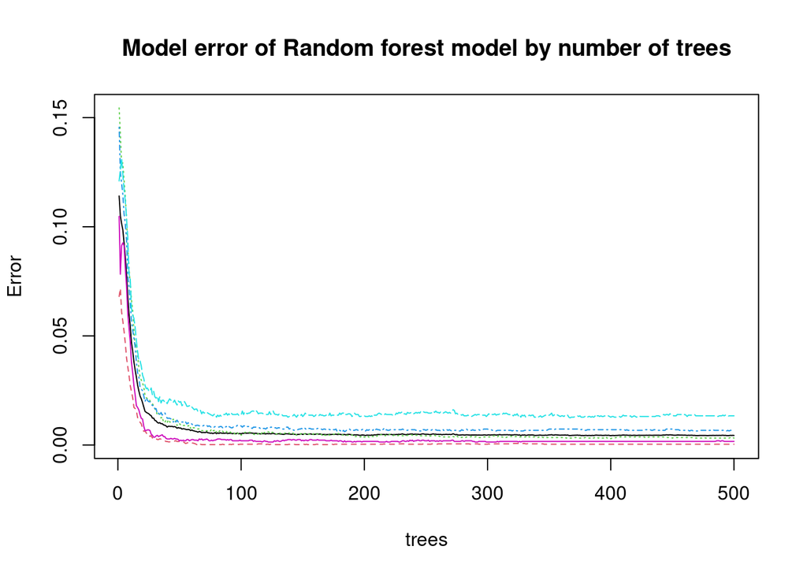

```r
plot(model_RF$finalModel,main="Model error of Random forest model by number of trees")
```

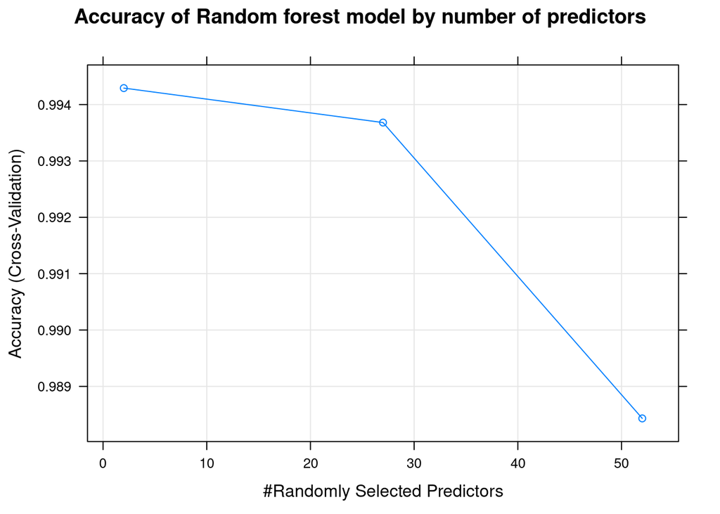

```r
plot(model_RF,main="Accuracy of Random forest model by number of predictors")
```

```r
MostImpVars <- varImp(model_RF)
MostImpVars
```

```
## rf variable importance
##
##   only 20 most important variables shown (out of 52)
##
##                   Overall
## roll_belt          100.00
## yaw_belt            84.68
## magnet_dumbbell_z   73.67
## pitch_belt          63.31
## magnet_dumbbell_y   63.23
## pitch_forearm       62.52
## roll_forearm        55.84
## magnet_dumbbell_x   52.84
## accel_belt_z        48.48
## accel_dumbbell_y    46.49
## magnet_belt_z       45.80
## roll_dumbbell       44.75
## magnet_belt_y       42.75
## roll_arm            39.18
## accel_dumbbell_z    39.12
## accel_forearm_x     34.31
## gyros_belt_z        32.20
## accel_dumbbell_x    31.05
## yaw_dumbbell        30.67
## gyros_dumbbell_y    29.71
```

```r
predfinalRF <- predict(model_RF,newdata=testingCleaned)
predfinalGBM <- predict(model_RF,newdata=testingCleaned)
predfinalGBM==predfinalRF
```

```
##  [1] TRUE TRUE TRUE TRUE TRUE TRUE TRUE TRUE TRUE TRUE TRUE TRUE TRUE TRUE TRUE
## [16] TRUE TRUE TRUE TRUE TRUE
```

```r
predfinalRF
```

```
##  [1] B A B A A E D B A A B C B A E E A B B B
## Levels: A B C D E
```